# Assignment 3

Manning Smith

2024-10-03

# Part 1

Suppose we have a hazard function $h(t)=c$, where $c$ is a constant. Please derive the corresponding survival function $S(t)$ and probability density function $f(t)$.

**Survival function:**
Given that $h(t)=c$. We derive the survival function $S(t)$ as:
$$h(t) = -\frac{d}{dt}ln(S(t))$$
given $h(t)=c$, we can substitute:
$$c = -\frac{d}{dt}ln(S(t))$$
Integrate both sides with respect to $t$:
$$\int c dt = - \int ln(S(t)) dt$$
see,
$$ct = - ln(S(t))$$
Let $ln(S(0))=0$,
$$ln(S(t)) = -ct$$
then take the exponentiation of each side,
$$S(t) = e^{-ct}$$

Or as the book has it as, $h(t)=\lambda$:
$$S(t) = e^{-\lambda t}$$

**PDF**
$$f(t) = -\frac{d}{dt} S(t)$$
Substitute for $S(t)=e^{-ct}$:
$$f(t) = -\frac{d}{dt} e^{-ct}$$
Differentiate,
$$f(t) = ce^{-ct}$$
Or as the book has it as, $h(t)=\lambda$:
$$f(t) = \lambda e^{-\lambda t}$$

# Part 2

High blood pressure is an important public health concern because it is highly prevalent and a risk factor for adverse health outcomes, including coronary heart disease, stroke, decompensated heart failure, chronic kidney disease, and decline in cognitive function, and death. A study was conducted with two strategies, one with the standard target of systolic blood pressure140 mm Hg(standard treatment), and the other targets a more intensive target of systolic blood pressure120 mm Hg (intensive treatment).

- Get familiar with the data. How many observations and variables (which type) are in the dataset?
- Estimate the survival curves using the Kaplan–Meier method for each treatment strategy. Show your survival data with censored time, and perform a test for possible differences, i.e., conduct a suitable test to examine the effect of intensive treatment.
- Conduct Univariate Cox regression to examine the impact of intensive treatment strategy on survival of patients.
- Conduct multivariate Cox Regression Analysis to examine the impact of the treatment strategy and other factors on the risk of death using hazard ratios.
- Conduct a suitable test and a graphical diagnostic for the proportional hazards assumption for the used Cox Regression modelling.

## Data Set Details:

- ID: patient ID
- Treat: 1: Intensive treatment; 0: Standard treatment
- Age: Patient age at baseline in years
- Gender: 1: Female, 0: Male
- Smoking: Smoking Status, 1: Yes, 0: No.
- Triglycerides: Baseline Triglycerides mg/dL
- BMI: Baseline Body Mass Index kg/m2
- total_DDD: Baseline defined daily dosage of antihypertensive medications.
- Death: All Cause Mortality in the follow-up time period. 1: Death; 0: Alive.
- Time: Follow-up time (years) or time to death from enrollment

## Import Data

```r
BPdata <- read.csv("BPIntensiveZZ-2-1.csv")
#BPdata <- na.omit(BPdata)

#View(BPdata)
```

##### Explore the Data

```r
summary(BPdata)
```

```
##       ID                Treat             Age            Gender
##  Length:9308        Min.   :0.0000   Min.   :46.00   Min.   :0.0000
##  Class :character   1st Qu.:0.0000   1st Qu.:61.00   1st Qu.:0.0000
##  Mode  :character   Median :0.0000   Median :67.00   Median :0.0000
##                     Mean   :0.4998   Mean   :67.89   Mean   :0.3554
##                     3rd Qu.:1.0000   3rd Qu.:75.00   3rd Qu.:1.0000
##                     Max.   :1.0000   Max.   :96.00   Max.   :1.0000
##
##     Smoking       Triglycerides       BMI          total_DDD
##  Min.   :0.0000   Min.   :  23   Min.   :13.73   Min.   : 0.000
##  1st Qu.:0.0000   1st Qu.:  77   1st Qu.:25.88   1st Qu.: 1.000
##  Median :0.0000   Median : 107   Median :29.02   Median : 2.000
##  Mean   :0.1328   Mean   : 126   Mean   :29.86   Mean   : 2.577
##  3rd Qu.:0.0000   3rd Qu.: 150   3rd Qu.:32.91   3rd Qu.: 3.667
##  Max.   :1.0000   Max.   :3340   Max.   :69.59   Max.   :22.000
##  NA's   :11       NA's   :22     NA's   :61      NA's   :47
##      Death              Time
##  Min.   :0.00000   Min.   :0.000
##  1st Qu.:0.00000   1st Qu.:3.300
##  Median :0.00000   Median :3.800
##  Mean   :0.04029   Mean   :3.671
##  3rd Qu.:0.00000   3rd Qu.:4.350
##  Max.   :1.00000   Max.   :5.490
##
```

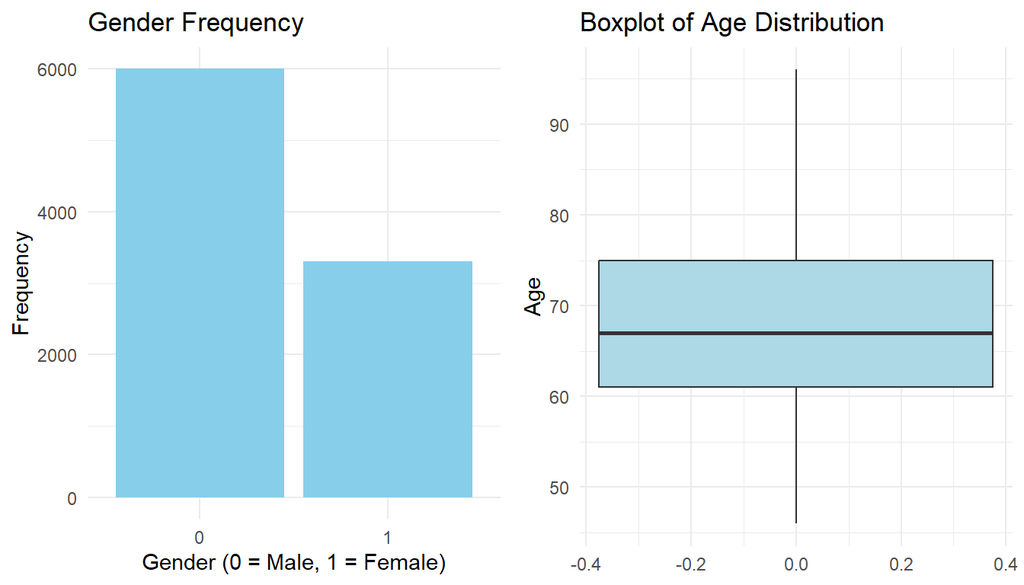

```r
p1 <- ggplot(BPdata, aes(x = as.factor(Gender))) +
  geom_bar(fill = "skyblue") +
  labs(x = "Gender (0 = Male, 1 = Female)", y = "Frequency", title = "Gender Frequency") +
  theme_minimal()

p2 <- ggplot(BPdata, aes(y = Age)) +
  geom_boxplot(fill = "lightblue") +
  labs(y = "Age", title = "Boxplot of Age Distribution") +
  theme_minimal()

p3 <- ggplot(BPdata, aes(x = as.factor(Gender), y = Age)) +
  geom_boxplot(fill = "lightblue") +
  labs(x = "Gender (0 = Male, 1 = Female)", y = "Age", title = "Age Distribution by Gender") +
  theme_minimal()

grid.arrange(p1, p2, ncol = 2, nrow = 1)
```

The size of the data is $n>9000$. There are some missing values, but there are complete results for atleast $9000$ observations. There is a good variability in age with a range of 46 to 96 and an average age of 67. For Gender, there are much more data points for males being about $6000$ and only ~$3000$ for females. There could lead to incorrect assumptions when generalizing based on a specific gender, but if you are making a generalization on a population this assumption should be safe.

##### Kaplan–Meier method

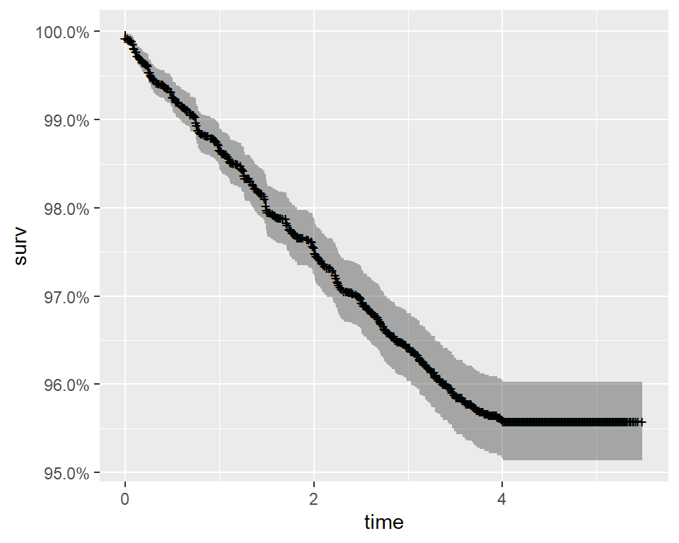

```r
km_fit <- survfit(Surv(Time, Death) ~ 1, data=BPdata)
#km_fit
autoplot(km_fit)
```

```r
km_fit_trt <- survfit(Surv(Time, Death) ~ Treat, data=BPdata)
km_fit_trt
```

```
## Call: survfit(formula = Surv(Time, Death) ~ Treat, data = BPdata)
##
##            n events median 0.95LCL 0.95UCL
## Treat=0 4656    213     NA      NA      NA
## Treat=1 4652    162     NA      NA      NA
```

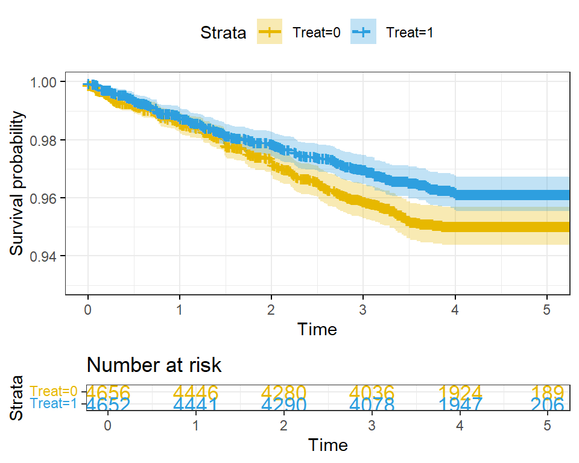

```r
ggsurvplot(km_fit_trt,
           pval = TRUE, conf.int = TRUE,
           risk.table = TRUE, # Add risk table
           risk.table.col = "strata", # Change risk table color by groups
           linetype = "strata", # Change line type by groups
           surv.median.line = "hv", # Specify median survival
           ylim = c(0.93, 1),
           ggtheme = theme_bw(), # Change ggplot2 theme
           palette = c("#E7B800", "#2E9FDF"))
```

```r
surv_diff <- survdiff(Surv(Time, Death) ~ Treat, data = BPdata)
surv_diff
```

```
## Call:
## survdiff(formula = Surv(Time, Death) ~ Treat, data = BPdata)
##
##            N Observed Expected (O-E)^2/E (O-E)^2/V
## Treat=0 4656      213      187      3.60      7.18
## Treat=1 4652      162      188      3.58      7.18
##
##  Chisq= 7.2  on 1 degrees of freedom, p= 0.007
```

The results from the Kaplan-Meier survival analysis suggest that there is a statistically significant difference in survival outcomes between patients receiving standard treatment and those receiving intensive treatment.

##### Univariate Cox Regression method

```r
uc_reg <- coxph(Surv(Time, Death) ~ Treat, data = BPdata)
uc_reg
```

```
## Call:
## coxph(formula = Surv(Time, Death) ~ Treat, data = BPdata)
##
##          coef exp(coef) se(coef)      z       p
## Treat -0.2785    0.7569   0.1042 -2.671 0.00755
##
## Likelihood ratio test=7.2  on 1 df, p=0.007273
## n= 9308, number of events= 375
```

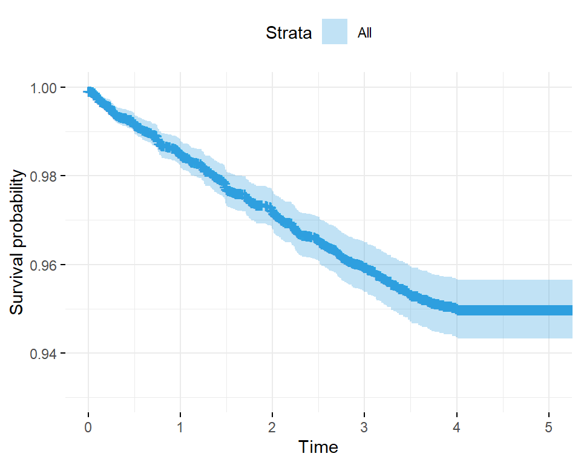

```r
ggsurvplot(survfit(uc_reg), color = "#2E9FDF",
           ylim = c(0.93, 1),
           ggtheme = theme_minimal(), data=BPdata)
```

The univariate Cox regression analysis suggests that intensive treatment is associated with a significantly reduced hazard of death in this dataset. Patients receiving intensive treatment have about a 24.3% lower risk of death compared to those receiving standard treatment, and this finding is statistically significant. Therefore, it supports the hypothesis that intensive treatment may be beneficial in reducing mortality risk.

##### Mutiariate Cox Regression method

```r
mult_reg <- coxph(Surv(Time, Death) ~ Treat + Age + Gender + Smoking + Triglycerides + BMI + total_DDD, data = BPdata)
mult_reg
```

```
## Call:
## coxph(formula = Surv(Time, Death) ~ Treat + Age + Gender + Smoking +
##     Triglycerides + BMI + total_DDD, data = BPdata)
##
##                     coef  exp(coef)   se(coef)      z        p
## Treat         -0.2845553  0.7523488  0.1052296 -2.704 0.006848
## Age            0.0785771  1.0817467  0.0063812 12.314  < 2e-16
## Gender        -0.4209925  0.6563950  0.1167065 -3.607 0.000309
## Smoking        1.0237997  2.7837522  0.1496975  6.839 7.97e-12
## Triglycerides  0.0010290  1.0010296  0.0004084  2.520 0.011744
## BMI            0.0025799  1.0025833  0.0105005  0.246 0.805917
## total_DDD      0.0535501  1.0550099  0.0234218  2.286 0.022235
##
## Likelihood ratio test=199.3  on 7 df, p=< 2.2e-16
## n= 9170, number of events= 368
##    (138 observations deleted due to missingness)
```

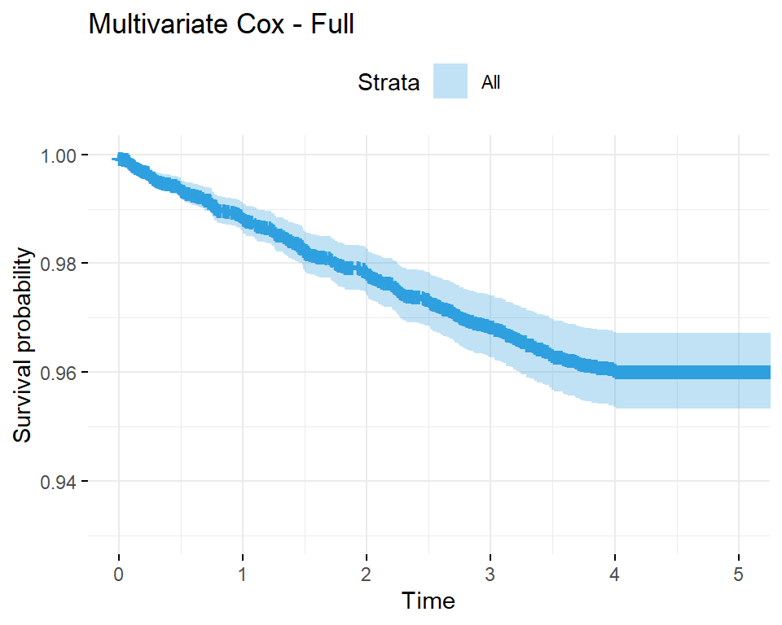

```r
ggsurvplot(survfit(mult_reg), color = "#2E9FDF",
           ylim = c(0.93, 1),
           ggtheme = theme_minimal(),
           title = "Multivariate Cox - Full",
           data=BPdata)
```

##### Mutiariate Cox Model Selection

```r
testPH <- cox.zph(mult_reg)
testPH
```

```
##                  chisq df    p
## Treat         0.245354  1 0.62
## Age           0.003052  1 0.96
## Gender        0.068313  1 0.79
## Smoking       1.813669  1 0.18
## Triglycerides 0.009678  1 0.92
## BMI           0.141346  1 0.71
## total_DDD     0.000241  1 0.99
## GLOBAL        2.458359  7 0.93
```

```r
mult_reg2 <- coxph(Surv(Time, Death) ~ Treat + Age + Gender + Smoking, data = BPdata)
mult_reg2
```

```
## Call:
## coxph(formula = Surv(Time, Death) ~ Treat + Age + Gender + Smoking,
##     data = BPdata)
##
##              coef exp(coef)  se(coef)      z        p
## Treat   -0.286750  0.750699  0.104391 -2.747 0.006016
## Age      0.075985  1.078946  0.005959 12.751  < 2e-16
## Gender  -0.410621  0.663238  0.115224 -3.564 0.000366
## Smoking  1.015347  2.760322  0.146082  6.951 3.64e-12
##
## Likelihood ratio test=191.1  on 4 df, p=< 2.2e-16
## n= 9297, number of events= 374
##    (11 observations deleted due to missingness)
```

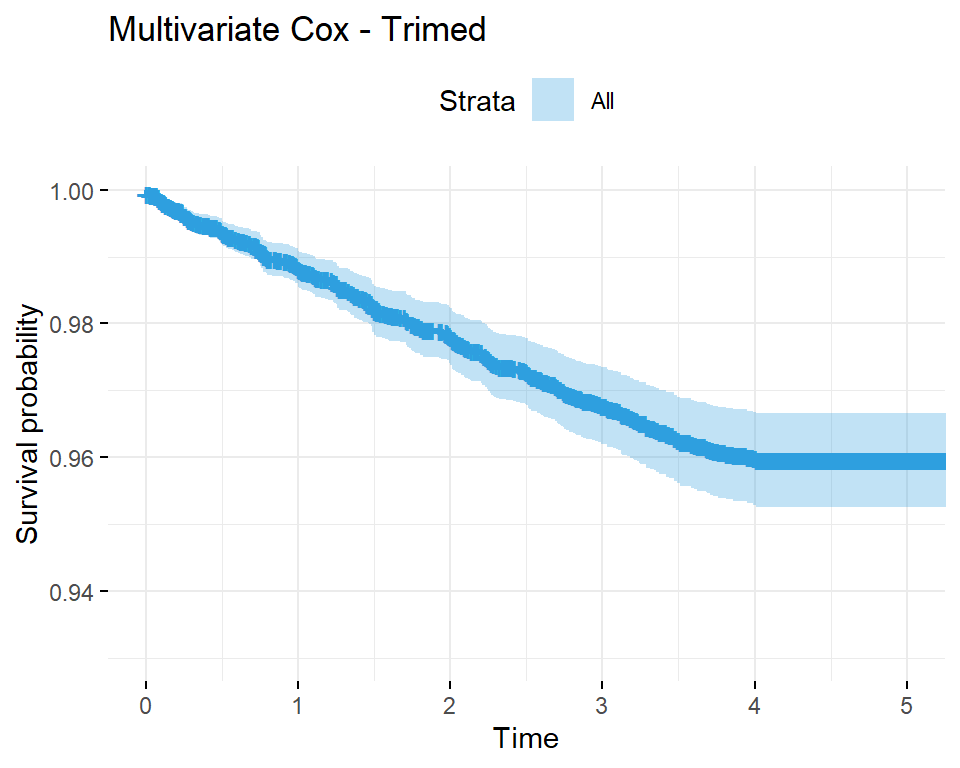

```r
ggsurvplot(survfit(mult_reg2), color = "#2E9FDF",
           ylim = c(0.93, 1),
           ggtheme = theme_minimal(),
           title = "Multivariate Cox - Trimed",
           data=BPdata)
```

Notice in the trimmed model, we get similar results but utilizing a few less variables.  
`Surv(Time, Death) ~ Treat + Age + Gender + Smoking`, This model resulted in similar results as the full model, but only adding in covariates for age, gender, and smoking. These indicators were the most influiencial in the outcome of the model.